# Stats 250: Lab 5 Assignment

Elan Grossman

2023-10-26

### Instructions

Complete the lab exercises and Dive Deeper questions below. Lab exercises will be graded out of 2 points each and the Dive Deeper questions will be graded out of 3 points each - all of them will be graded for *correctness*. Upon completion, follow the submission instructions at the bottom of this document. We strongly encourage you to work on this assignment with a partner, but each student must submit their own lab assignment.

### Background

[Source](https://www.kaggle.com/datasets/stefanoleone992/fifa-22-complete-player-dataset)

FIFA is a popular soccer video game developed by EA Sports. Listed as the best-selling sports video game in the world, FIFA allows gamers to play soccer matches using real players from all over the world. This data set contains information for **every** soccer player competing in the MLS (the most popular soccer league in the US). In other words, this data set contains *the population of all soccer players in the MLS*. (Note: goalkeepers have been removed.) The original file contains over 50 attributes for every player, but we have narrowed it down to the following eight variables.

1. `club`: team
2. `positions`: a list of positions (ST - striker, CB - center back, etc.)
3. `height`: height (in cm)
4. `salary`: annual salary (in $1000’s)
5. `speed`: speed (out of 100)
6. `shooting`: shooting ability (out of 100)
7. `dribbling`: dribbling ability (out of 100)
8. `defending`: defending ability (out of 100)

Use the following code chunk to read in the data set.

```r
fifa <- read.csv("fifa.csv", row.names = 1)
```

You can preview the data below.

```r
head(fifa)
```

```
##                                         club positions height salary speed
## Aaron Herrera                 Real Salt Lake    RB, LB  180.3 111.28    68
## Aaron Long                New York Red Bulls        CB  185.4 500.76    80
## Aaron Maxwell Schoenfeld           Austin FC        ST  193.2 111.28    62
## Abdoulaye Cissoko        Seattle Sounders FC        CB  190.7  50.08    61
## Aboubacar Kobele Keita         Columbus Crew        CB  189.8  55.64    80
## Abu Danladi                     Nashville SC    ST, RM  178.2 111.28    76
##                          shooting dribbling defending
## Aaron Herrera                  32        62        65
## Aaron Long                     40        64        74
## Aaron Maxwell Schoenfeld       61        58        29
## Abdoulaye Cissoko              28        45        57
## Aboubacar Kobele Keita         27        50        63
## Abu Danladi                    63        64        39
```

And be sure to load in the required packages!

```r
library(stats250package)
library(ggplot2)
library(ggdist)
```

### Lab Exercises

After reading the background above, complete the following lab exercises. Remember, these exercises are worth 2 points each and are graded for *correctness*.

> 1. After reading the background above, you are posed with two questions: (1) what percentage of MLS players are listed as strikers (ST)? and (2) what is the average height of an MLS player? For each question, identify the type (categorical or quantitative) for the variable of interest. Then, decide whether calculating a proportion or mean would be a more useful summary measure to answer the posed question. Note: you do not have to identify the sub-type (nominal/ordinal, continuous/discrete).

`positions`

- *Variable Type:* categorical
- *Summary Measure:* proportion

`height`

- *Variable Type:* quantitative
- *Summary Measure:* mean
> 2. Using `ggplot()` create a histogram for the heights of all MLS soccer players. Be sure to include appropriate axis labels and a title. Comment on the shape of the histogram and eyeball the approximate mean (center).

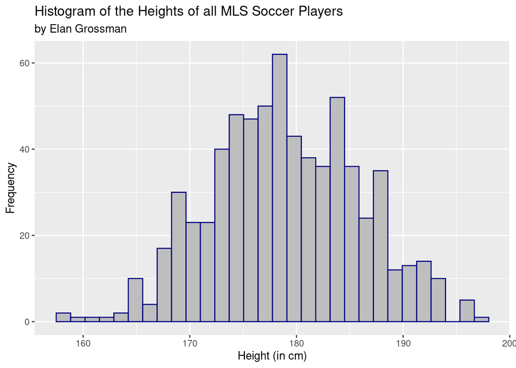

```r
ggplot(data = fifa, aes(x = height)) +
  geom_histogram(bins = 30,
                 color = "navy",
                 fill = "gray")+
   labs(title = "Histogram of the Heights of all MLS Soccer Players",
       subtitle = "by Elan Grossman",
       x = "Height (in cm)",
       y = "Frequency")
```

*Answer:* The shape of this histogram is unimodal with a slight skew to the left. The approximate mean is 178 cm.

> 3. With the height variable and the `simMeans()` function, simulate the sampling distribution of the sample mean for random samples of size *10*. What does each dot in the plot represent? Be specific and provide context!

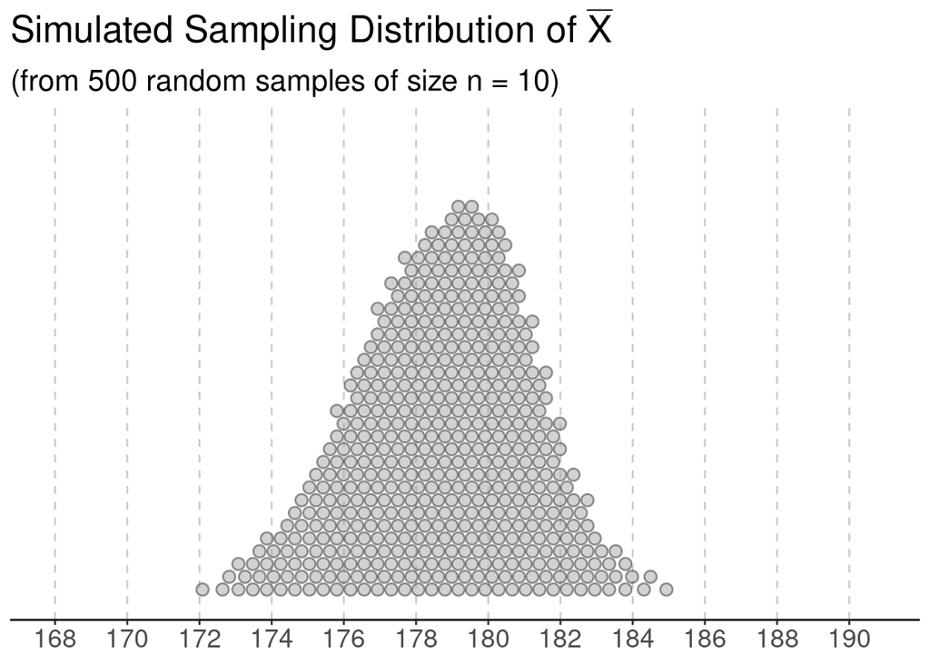

```r
simMeans(fifa$height, n = 10)
```

*Answer:* Each dot represents average height (in cm) of a random sample of n=10 MLS players.

> 4. With the height variable and the `simMeans()` function, create the sampling distribution of the sample mean for random samples of size *20*. The resulting plot and your plot from Exercise 3 should result in bell-shaped (normal) sampling distributions. The Central Limit Theorem states that we need to take random samples of at least size 25 in order for the resulting sampling distribution to be approximately normal – so why are these sampling distributions normal even though we have sample sizes less than 25?

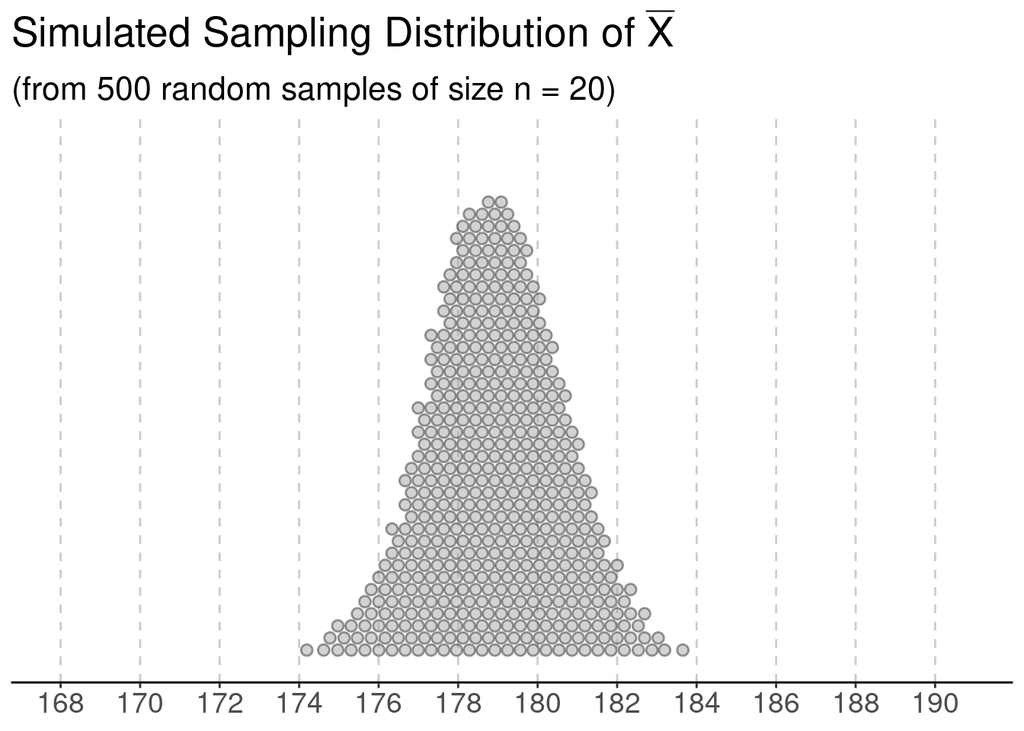

```r
simMeans(fifa$height, n = 20)
```

*Answer:* These sampling distributions are normal although we have a sample size less than 25 because the population distribution, the original distribution of all heights, is normal. Therefore, we do not need to rely on the CLT, central limit theorem.

> 5. Pick a different *quantitative* variable from the FIFA data set. Create a histogram for your chosen variable. Be sure to include appropriate axis labels and a title. Comment on the shape of the histogram and eyeball the approximate mean (center).

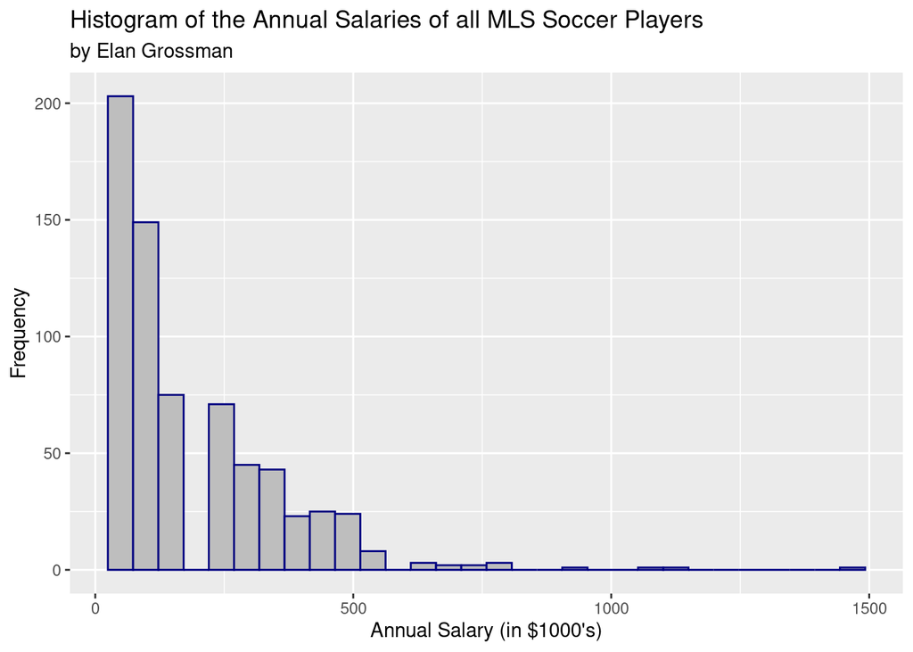

```r
ggplot(data = fifa, aes(x = salary)) +
  geom_histogram(bins = 30,
                 color = "navy",
                 fill = "gray")+
   labs(title = "Histogram of the Annual Salaries of all MLS Soccer Players",
       subtitle = "by Elan Grossman",
       x = "Annual Salary (in $1000's)",
       y = "Frequency")
```

```r
summary(fifa$salary)
```

```
##    Min. 1st Qu.  Median    Mean 3rd Qu.    Max.
##   27.82   55.64  111.28  190.26  278.20 1446.64
```

*Answer:* The histogram is unimodal and skewed heavily to the right. There is a range of roughly 1,400 * 1000 dollars. The center of the distribution is roughly 111 * 1000 dollars.

> 6. With the variable you picked in Exercise 5 and the `simMeans()` function, create the sampling distribution of the sample mean for random samples of size *25*. What does each dot in the plot represent? Be specific and provide context!

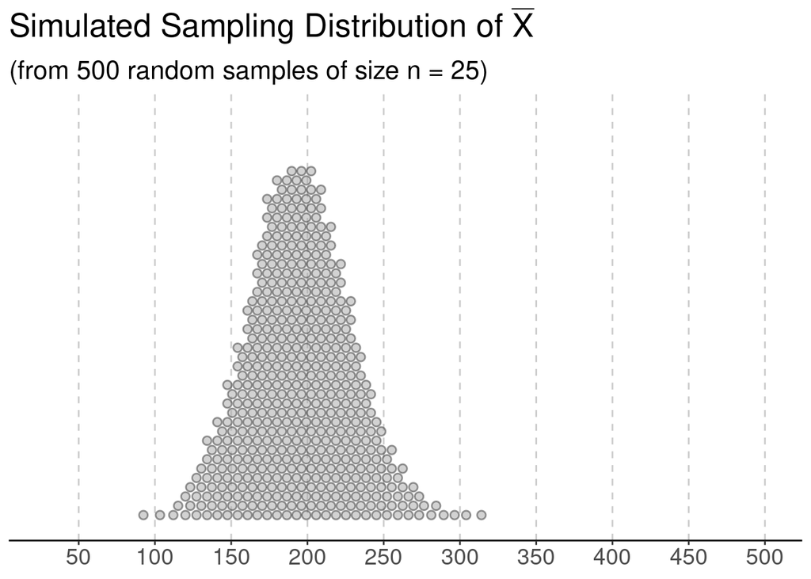

```r
simMeans(fifa$salary, n = 25)
```

*Answer:* Each dot represents the average annual salary in $1000’s of a random sample of n = 25 MLS players.

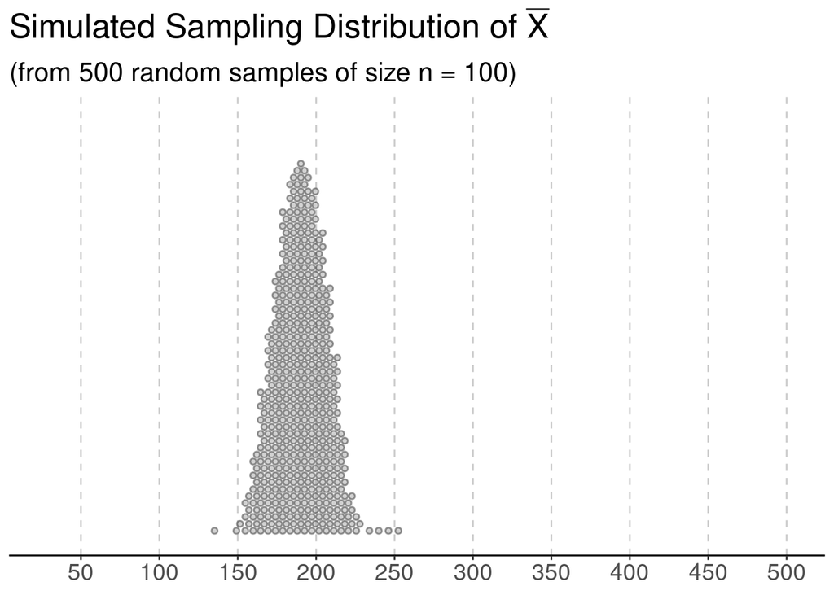

```r
simMeans(fifa$salary, n =100)
```

### Dive Deeper Questions

After completing the lab exercises above, complete the following Dive Deeper questions. Remember, these questions are worth 3 points each and are graded for correctness.

> **1.** A student decided to analyze the `defending` variable in Exercises 5 - 7 and made the following *incorrect* statement. *“With a large sample size of 100, the distribution of defensive abilities for the sample of 100 players will be approximately normal because of the Central Limit Theorem.”* Rewrite the statement to correctly reflect the CLT.

*Answer:* Since the sample size n=100 is greater than or equal to 25, we can assume that the distribution of all possible sample mean values of defensive abilities is approximately normal because of the Central Limit Theorem.

> **2.** Another variable included in the original data set was *overall* - which measures the overall skill of a player (out of 100 points). The sampling distribution of the sample mean for random samples of size *50* was created and is provided below. The sampling distribution is bell-shaped, but what about the population distribution for the `overall` variable? Can we determine if the shape of the population distribution for the `overall` variable is also normally distributed? In other words, if we were to plot the histogram of the variable overall skill for all 680 MLS players, do we know whether the histogram will follow a normal distrbution (based on the sampling distribution provided below)? Why or why not?

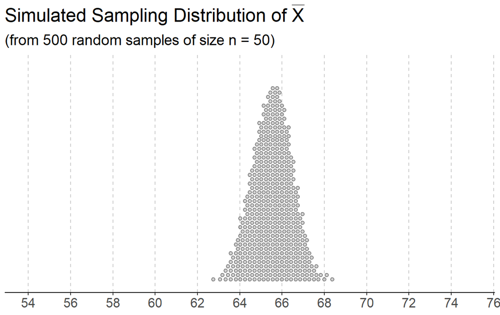

*Answer:* If I was to plot the histogram for the variable ‘overall skill’ for all 680 MLS players, the population distribution, we would not be able to tell if it follows a normal distribution. This is because 50 is greater than 25, and the simulated sampling distribution would be normal because of the Central Limit Theorem. However, we can’t conclude whether the population will also be normal.

### Submission Instructions

Once you have finished, follow the instructions below to submit your work.

1. At the top of the document, update the `author` field. *Do not change anything else at the top of the document.*
2. Click the Knit button to create an HTML file of your work.
3. In the Files pane (bottom right window), check the box next to `lab05_assignment.html`.
4. In the Files pane, click on the gear icon (More) and select “Export…”
5. Do not change the file name (`lab05_assignment.html`). Click Download and save the file to your computer.
6. On the Stats 250 Canvas site, navigate to the Lab 5 assignment.
7. Upload your saved `lab05_assignment.html` file.
8. Click “Submit Assignment”. Congratulations, you are done with Lab 5!